# Plotting and Analysis with zoomstudentengagement

zoomstudentengagement package

2025-08-03

```r
library(zoomstudentengagement)
library(dplyr)
library(ggplot2)
```

# Plotting and Analysis

This vignette shows how to create visualizations and analyze student engagement patterns using the `zoomstudentengagement` package.

## Preparing Data for Analysis

### Loading Sample Data

First, let’s prepare some sample data for analysis:

```r
# Create sample data for demonstration
# In practice, you would load actual transcript and roster data

# Sample transcript metrics
transcripts_metrics_df <- tibble::tibble(
  name = c("Alice Johnson", "Bob Smith", "Carol Davis", "David Wilson", "Eva Brown"),
  n = c(8, 12, 5, 15, 3),
  duration = c(45.2, 67.8, 23.1, 89.4, 12.5),
  wordcount = c(1200, 1800, 650, 2200, 400),
  comments = list("Good point", "Interesting question", "I agree", "Follow-up question", "Brief comment"),
  n_perc = c(18.6, 27.9, 11.6, 34.9, 7.0),
  duration_perc = c(19.2, 28.8, 9.8, 38.0, 5.3),
  wordcount_perc = c(19.2, 28.8, 10.4, 35.2, 6.4),
  wpm = c(26.5, 26.6, 28.1, 24.6, 32.0),
  course_section = "LTF.201.1",
  course = 201,
  section = 1,
  day = "Thursday",
  time = "18:30",
  name_raw = name,
  start_time_local = as.POSIXct("2024-01-24 18:30:00", tz = "America/Los_Angeles"),
  dept = "LTF",
  session_num = 1
)

# Sample roster sessions
roster_sessions <- tibble::tibble(
  student_id = c("12345", "12346", "12347", "12348", "12349"),
  first_last = c("Alice Johnson", "Bob Smith", "Carol Davis", "David Wilson", "Eva Brown"),
  preferred_name = c("Alice", "Bob", "Carol", "David", "Eva"),
  dept = "LTF",
  course = 201,
  section = 1,
  session_num = 1,
  start_time_local = as.POSIXct("2024-01-24 18:30:00", tz = "America/Los_Angeles"),
  course_section = "LTF.201.1"
)

# Create clean names dataframe
# Use a temporary directory since we're working with sample data
temp_dir <- tempdir()
clean_names_df <- make_clean_names_df(
  data_folder = temp_dir,
  section_names_lookup_file = "section_names_lookup.csv",
  transcripts_metrics_df,
  roster_sessions
)
# Create summary dataframes
transcripts_session_summary_df <- make_transcripts_session_summary_df(clean_names_df)
transcripts_summary_df <- make_transcripts_summary_df(transcripts_session_summary_df)

# View the summary data
head(transcripts_summary_df)
```

```
#> # A tibble: 5 × 10
#>   section preferred_name session_ct     n duration wordcount   wpm perc_n
#>   <chr>   <chr>               <int> <int>    <dbl>     <dbl> <dbl>  <dbl>
#> 1 1       David                   1     1     89.4      2200  24.6     20
#> 2 1       Bob                     1     1     67.8      1800  26.5     20
#> 3 1       Alice                   1     1     45.2      1200  26.5     20
#> 4 1       Carol                   1     1     23.1       650  28.1     20
#> 5 1       Eva                     1     1     12.5       400  32       20
#> # ℹ 2 more variables: perc_duration <dbl>, perc_wordcount <dbl>
```

## Basic Visualization

### Plotting by Metric

The `plot_users_by_metric()` function creates visualizations for different engagement metrics:

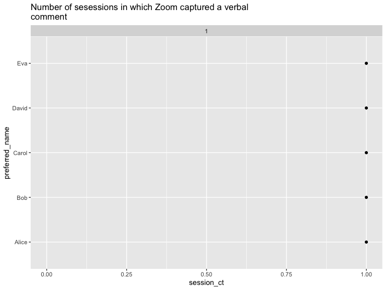

```r
# Plot session count
plot_users_by_metric(transcripts_summary_df, metric = "session_ct")
```

[figure not shown]

```r
# Plot comment count
plot_users_by_metric(transcripts_summary_df, metric = "n")
```

[figure not shown]

```r
# Plot speaking duration
plot_users_by_metric(transcripts_summary_df, metric = "duration")
```

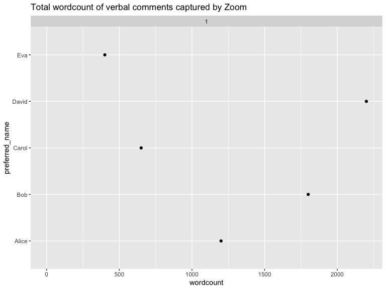

```r
# Plot word count
plot_users_by_metric(transcripts_summary_df, metric = "wordcount")
```

## Understanding the Metrics

### Percentage Metrics

Visualize relative participation:

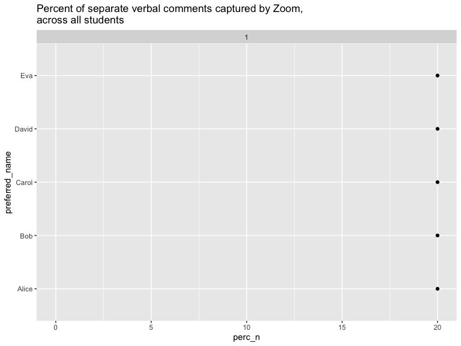

```r
# Plot percentage of comments
plot_users_by_metric(transcripts_summary_df, metric = "perc_n")
```

[figure not shown]

```r
# Plot percentage of speaking time
plot_users_by_metric(transcripts_summary_df, metric = "perc_duration")
```

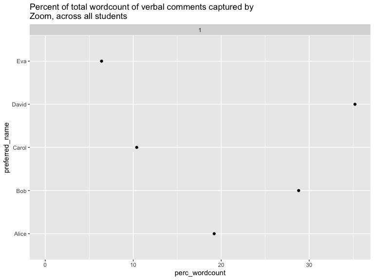

```r
# Plot percentage of words
plot_users_by_metric(transcripts_summary_df, metric = "perc_wordcount")
```

## Students-Only Analysis

### Filtering for Enrolled Students

Focus analysis on enrolled students only:

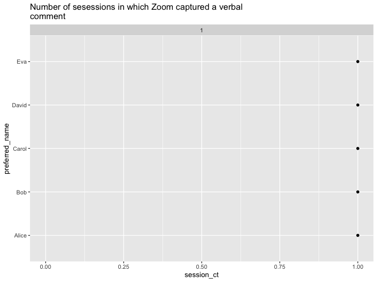

```r
# Create students-only summary
students_only_summary <- make_students_only_transcripts_summary_df(
  transcripts_session_summary_df
)

# Plot students-only metrics
plot_users_by_metric(students_only_summary, metric = "session_ct")
```

### Masked Names for Privacy

Use masked names for privacy-conscious analysis:

[figure not shown]

```r
# Plot with masked names
plot_users_masked_section_by_metric(
  df = students_only_summary,
  metric = "n"
)
```

[figure not shown]

```r
plot_users_masked_section_by_metric(
  df = students_only_summary,
  metric = "duration"
)
```

## Advanced Analysis

### Custom Filtering

Filter data for specific analysis:

[figure not shown]

```r
# Filter for specific sections
section_data <- transcripts_summary_df %>%
  filter(section == 1) # Use the actual section number from our sample data

# Plot filtered data
plot_users_by_metric(section_data, metric = "wpm")
```

### Comparative Analysis

Compare different metrics:

[figure not shown]

```r
# Create comparison plots
par(mfrow = c(2, 2))
plot_users_by_metric(transcripts_summary_df, metric = "n")
```

[figure not shown]

```r
plot_users_by_metric(transcripts_summary_df, metric = "duration")
```

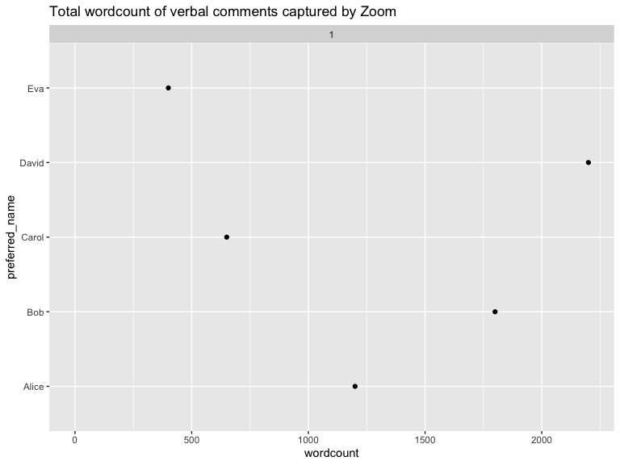

```r
plot_users_by_metric(transcripts_summary_df, metric = "wordcount")
```

[figure not shown]

```r
plot_users_by_metric(transcripts_summary_df, metric = "wpm")
```

## Interpreting the Results

### Participation Equity

Look for patterns in participation:

```r
# Analyze participation distribution
participation_summary <- transcripts_summary_df %>%
  group_by(section) %>%
  summarise(
    total_students = n(),
    active_students = sum(n > 0),
    avg_comments = mean(n),
    median_comments = median(n),
    participation_rate = active_students / total_students
  )

participation_summary
```

```
#> # A tibble: 1 × 6
#>   section total_students active_students avg_comments median_comments
#>   <chr>            <int>           <int>        <dbl>           <int>
#> 1 1                    5               5            1               1
#> # ℹ 1 more variable: participation_rate <dbl>
```

### Engagement Patterns

Identify different types of engagement:

```r
# Categorize students by engagement type
engagement_categories <- transcripts_summary_df %>%
  mutate(
    engagement_type = case_when(
      n == 0 ~ "No participation",
      n <= 2 ~ "Low participation",
      n <= 5 ~ "Moderate participation",
      TRUE ~ "High participation"
    )
  ) %>%
  count(engagement_type)

engagement_categories
```

```
#> # A tibble: 1 × 2
#>   engagement_type       n
#>   <chr>             <int>
#> 1 Low participation     5
```

## Custom Visualizations

### Creating Your Own Plots

Use the data to create custom visualizations:

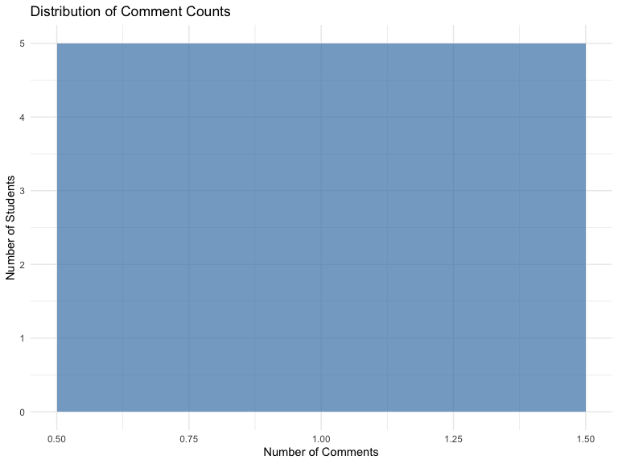

```r
# Custom participation distribution
ggplot(transcripts_summary_df, aes(x = n)) +
  geom_histogram(binwidth = 1, fill = "steelblue", alpha = 0.7) +
  labs(
    title = "Distribution of Comment Counts",
    x = "Number of Comments",
    y = "Number of Students"
  ) +
  theme_minimal()
```

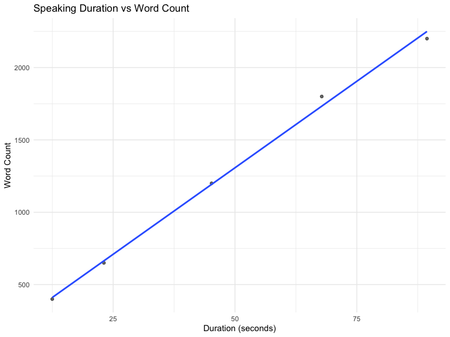

```r
# Custom duration vs word count
ggplot(transcripts_summary_df, aes(x = duration, y = wordcount)) +
  geom_point(alpha = 0.6) +
  geom_smooth(method = "lm", se = FALSE) +
  labs(
    title = "Speaking Duration vs Word Count",
    x = "Duration (seconds)",
    y = "Word Count"
  ) +
  theme_minimal()
```

## Best Practices

### Choosing the Right Metric

- **For attendance**: Use `session_ct`
- **For participation frequency**: Use `n` or `perc_n`
- **For speaking time**: Use `duration` or `perc_duration`
- **For content contribution**: Use `wordcount` or `perc_wordcount`
- **For speaking pace**: Use `wpm`

### Privacy Considerations

- Use masked names when sharing results
- Consider aggregating data for small groups
- Be mindful of FERPA compliance requirements

### Visualization Tips

- Use consistent color schemes
- Include clear titles and labels
- Consider log scales for skewed distributions
- Add context (e.g., class averages, benchmarks)

## Next Steps

- **For session mapping**: See the Session Mapping vignette
- **For student reports**: See the Student Reports vignette
- **For troubleshooting**: See the Troubleshooting Guide vignette